# hw04

Michael Puchalski

2025-02-10

```r
library(tidyverse,LaTeX)
df<-read.table("copier.txt", header = TRUE)
```

# 1. (R required) We will use the dataset “Copier.txt” for this question. The Tri-City Office Equipment Corporation sells an imported copier on a franchise basis and performs preventive maintenance and repair service on this copier. The data have been collected from 45 recent calls on users to perform routine preventive maintenance service; for each call, Serviced is the number of copiers serviced and Minutes is the total number of minutes spent by the service person.

## (a) What is the response variable in this analysis? What is predictor in this analysis?

In this analysis the response variable is “minutes”, as in the total number of minutes spent by the service person. The predictor is “Serviced”, the total number of copiers serviced. ## (b) Produce a scatterplot of the two variables. How would you describe the relationship between the number of copiers serviced and the time spent by the service person?

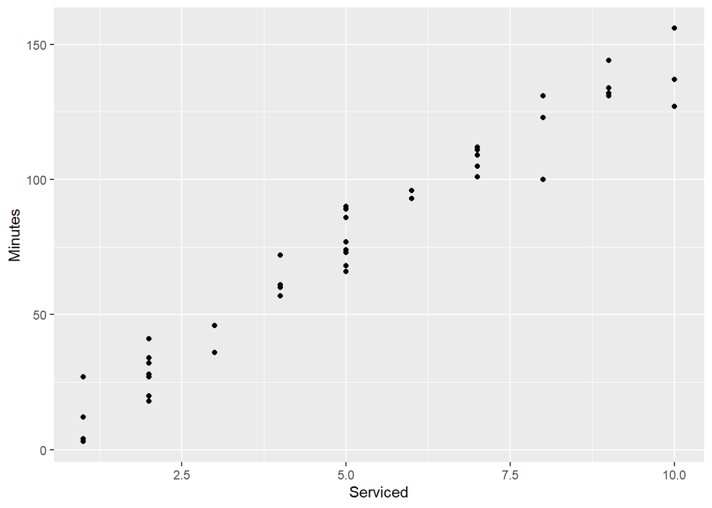

```r
ggplot(df, aes(x = Serviced, y = Minutes))+
  geom_point()
```

I would describe this, at least qualitatively, as a positive linear relationship between copiers serviced and the time spent doing so. ## (c) What is the correlation between the total time spent by the service person and the number of copiers serviced? Interpret this correlation contextually. As mentioned above, this correlates as a positive linear relationshp. This means that the more opiers there are to be serviced, the more total time that there will be spent on servicing the copiers. ## (d) Can the correlation found in part 1c be interpreted reliably? Briefly explain. It can be interpreted yes, but to do so reliabley, a linear model needs to be applied to it in order to ensure that any interpretations made are done so with minimal human bias ## (e) Use the lm() function to fit a linear regression for the two variables. Where are the values of βˆ 1, βˆ 0, R2 , and ˆσ 2 for this linear regression?

```r
lm_result<- lm(Minutes~Serviced, data = df)
summary(lm_result)
```

```
##
## Call:
## lm(formula = Minutes ~ Serviced, data = df)
##
## Residuals:
##      Min       1Q   Median       3Q      Max
## -22.7723  -3.7371   0.3334   6.3334  15.4039
##
## Coefficients:
##             Estimate Std. Error t value Pr(>|t|)
## (Intercept)  -0.5802     2.8039  -0.207    0.837
## Serviced     15.0352     0.4831  31.123   <2e-16 ***
## ---
## Signif. codes:  0 '***' 0.001 '**' 0.01 '*' 0.05 '.' 0.1 ' ' 1
##
## Residual standard error: 8.914 on 43 degrees of freedom
## Multiple R-squared:  0.9575, Adjusted R-squared:  0.9565
## F-statistic: 968.7 on 1 and 43 DF,  p-value: < 2.2e-16
```

B1 = 15.0352, B0 = -0.5802, R squared = 0.9575, sigma squared -> variance = 79.4594 B1 comes from the Serviced Estimate, B2 comes from the Intercept Estimate, R squared is the unadjusted value from the model. Variance is the Residual standard Error squared. ## (f) Interpret the values of βˆ 1, βˆ 0 contextually. Does the value of βˆ0 make sense in this context? The B1 value (the slope), describes how for every 1 machine serviced, there is an expected service time of 15 minutes. The B0 value (the y-intercept), is a negative value, however, this makes sense because there is no service time when there is no machine to be serviced. ## (g) Use the anova() function to produce the ANOVA table for this linear regression. What is the value of the ANOVA F statistic? What null and alternative hypotheses are being tested here? What is a relevant conclusion based on this ANOVA F statistic?

```r
anova(lm_result)
```

```
## Analysis of Variance Table
##
## Response: Minutes
##           Df Sum Sq Mean Sq F value    Pr(>F)
## Serviced   1  76960   76960  968.66 < 2.2e-16 ***
## Residuals 43   3416      79
## ---
## Signif. codes:  0 '***' 0.001 '**' 0.01 '*' 0.05 '.' 0.1 ' ' 1
```

The F statistic here is 968.66. The null hypothesis H0 =0, alternative ha does not equal 0. The relevant conclusion to be made here is based on the very high F statistic, the null hypothesis is rejected meaning the variance is explained more by the model than the error terms.